# 5 - Clustering with K-Means: discovering groups of patients

In chapter 5, Lucy asks the team a new kind of question: can we identify groups of patients at risk *before* they become ill? This time there are no labels. Nobody knows which groups exist, so the models of the previous chapters, which learn from examples with a known answer, cannot be used. Martha proposes **unsupervised learning**: let the algorithm discover the groups that naturally exist in the data, based on how similar the patients are. As she warns, the algorithm does not *understand* what a patient is; it only compares numbers with a similarity rule that we choose.

In this notebook:

1. Import the libraries.
2. K-Means by hand, step by step (Martha's notes, section 5.4).
3. Local optima and the initialization: K-Means++.
4. The Minermont patient population.
5. Why the features must be scaled.
6. Choosing $K$: the elbow method.
7. The five groups and their clinical interpretation.
8. The variables we include decide the groups.
9. Assigning a new patient to a group.

### Step 1: Import the libraries

```python
import numpy as np
import pandas as pd
import matplotlib.pyplot as plt
from sklearn.preprocessing import StandardScaler
from sklearn.cluster import KMeans
from sklearn.metrics import adjusted_rand_score
```

### Step 2: K-Means by hand

K-Means divides $n$ points into $K$ groups (**clusters**), each represented by its **centroid** $\mu_k$. It alternates two steps:

1. **Assignment**: each point goes to the cluster whose centroid is closest (squared Euclidean distance): $$C(i) = \arg\min_k \|x_i - \mu_k\|^2$$
2. **Update**: each centroid is recalculated as the mean of the points assigned to it: $$\mu_k = \frac{1}{|S_k|} \sum_{x_i \in S_k} x_i$$

and repeats them until the centroids stop moving. As Martha points out, the centroids "don't move like objects": we simply recalculate their position after each reassignment. The quantity that K-Means reduces is the **sum of squared errors (SSE)**, or **inertia**, the sum of the squared distances from each point to its centroid:

$$\text{SSE} = \sum_{k=1}^{K} \sum_{x_i \in S_k} \|x_i - \mu_k\|^2$$

We try it on 150 points in two dimensions, generated around three centers, starting from three arbitrary centroids:

```python
rng = np.random.default_rng(3)
X_toy = np.vstack([rng.normal(center, 0.8, (50, 2)) for center in [[2, 2], [7, 3], [4.5, 7]]])

def sse(X, labels, centroids):
    return sum(np.sum((X[labels == k] - c) ** 2) for k, c in enumerate(centroids))

def kmeans(X, centroids, max_iter=50):
    """K-Means by hand. Returns the final centroids, the labels, the SSE of each iteration and the history of centroids."""
    history, sses = [centroids.copy()], []
    for _ in range(max_iter):
        distances = np.sum((X[:, None, :] - centroids[None, :, :]) ** 2, axis=2)   # points x centroids
        labels = distances.argmin(axis=1)                                           # 1. assignment
        sses.append(sse(X, labels, centroids))
        new_centroids = np.array([X[labels == k].mean(axis=0) for k in range(len(centroids))])  # 2. update
        if np.allclose(new_centroids, centroids):
            break
        centroids = new_centroids
        history.append(centroids.copy())
    return centroids, labels, sses, history

start = np.array([[2.0, 7.0], [3.0, 6.0], [4.0, 5.0]])
centroids, labels, sses, history = kmeans(X_toy, start)
print(f"Iterations: {len(sses)}")
print("SSE at each iteration:", [round(float(s), 1) for s in sses])
```

```
Iterations: 10
SSE at each iteration: [1633.3, 909.3, 842.9, 827.8, 818.9, 806.2, 737.2, 396.2, 194.5, 194.0]
```

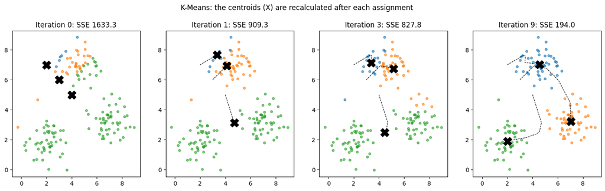

```python
colors = np.array(['tab:blue', 'tab:orange', 'tab:green'])
steps = [0, 1, 3, len(history) - 1]
fig, axes = plt.subplots(1, 4, figsize=(18, 4.5))
for ax, t in zip(axes, steps):
    c = history[t]
    lab = np.sum((X_toy[:, None, :] - c[None]) ** 2, axis=2).argmin(axis=1)
    ax.scatter(*X_toy.T, c=colors[lab], s=15, alpha=0.6)
    path = np.array(history[:t + 1])
    for k in range(3):
        ax.plot(path[:, k, 0], path[:, k, 1], 'k--', linewidth=0.8)
    ax.scatter(*c.T, c='k', marker='X', s=200)
    ax.set_title(f'Iteration {t}: SSE {sse(X_toy, lab, c):.1f}')
plt.suptitle('K-Means: the centroids (X) are recalculated after each assignment', y=1.02)
plt.show()
```

The SSE never goes up: it falls from 1633.3 to 194.0 in 10 iterations, and the algorithm stops when the centroids no longer move. In the plots, the three centroids start on a diagonal and each one travels, iteration after iteration, towards the centre of one of the three groups.

### Step 3: Local optima and the initialization

Martha's notes add an important warning: K-Means always converges, but it can converge to a **local optimum**, a stable grouping that is not the best possible one. It depends on where the centroids start. Let's start from three centroids placed side by side at the top of the plot:

```
Good start: final SSE 194.0
Bad start:  final SSE 680.1
```

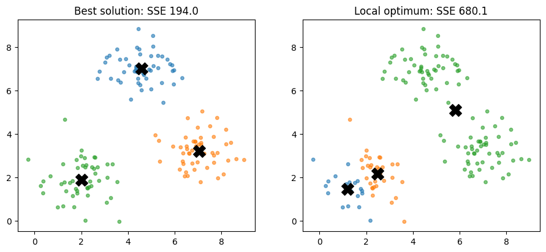

```python
bad_start = np.array([[1.0, 7.0], [2.0, 7.0], [3.0, 7.0]])
bad_centroids, bad_labels, bad_sses, _ = kmeans(X_toy, bad_start)
print(f"Good start: final SSE {sses[-1]:.1f}")
print(f"Bad start:  final SSE {bad_sses[-1]:.1f}")

fig, axes = plt.subplots(1, 2, figsize=(11, 4.5))
for ax, lab, c, title in [(axes[0], labels, centroids, f'Best solution: SSE {sses[-1]:.1f}'),
                          (axes[1], bad_labels, bad_centroids, f'Local optimum: SSE {bad_sses[-1]:.1f}')]:
    ax.scatter(*X_toy.T, c=colors[lab], s=15, alpha=0.6)
    ax.scatter(*c.T, c='k', marker='X', s=200)
    ax.set_title(title)
plt.show()
```

From this start the algorithm also converges, but to a grouping with an SSE of 680.1, three and a half times worse than the best one: two centroids share the group at the bottom left and a single centroid covers the other two groups. From there, no reassignment lowers the SSE, so the algorithm stops.

Two remedies are common. The first is to run the algorithm several times from different random starts and keep the solution with the lowest SSE. The second is **K-Means++**, which chooses better starting centroids: the first one is a random point, and each of the next ones is chosen at random with probability proportional to $D(x)^2$, the squared distance from each point to the nearest centroid already chosen. Distant points are therefore more likely to be chosen, and the centroids start spread out. We compare 200 random starts of each kind:

```python
def random_start(X, k, rng):
    return X[rng.choice(len(X), k, replace=False)]

def kmeans_plus_plus_start(X, k, rng):
    chosen = [X[rng.integers(len(X))]]
    for _ in range(1, k):
        d2 = np.min(np.sum((X[:, None, :] - np.array(chosen)[None]) ** 2, axis=2), axis=1)   # D(x)^2
        chosen.append(X[rng.choice(len(X), p=d2 / d2.sum())])
    return np.array(chosen)

best_sse = sses[-1]
for name, starter, offset in [('random points', random_start, 0), ('K-Means++', kmeans_plus_plus_start, 1000)]:
    finals = [kmeans(X_toy, starter(X_toy, 3, np.random.default_rng(offset + s)))[2][-1] for s in range(200)]
    stuck = np.sum(np.array(finals) > best_sse + 1)
    print(f"Start with {name:<14}: {stuck} of 200 runs end in a local optimum")

sk = KMeans(n_clusters=3, init='k-means++', n_init=10, random_state=0).fit(X_toy)
print(f"\nscikit-learn (K-Means++, best of 10 starts): SSE {sk.inertia_:.1f}")
```

```
Start with random points : 19 of 200 runs end in a local optimum
Start with K-Means++     : 9 of 200 runs end in a local optimum

scikit-learn (K-Means++, best of 10 starts): SSE 194.0
```

With random starting points, 19 of the 200 runs get stuck; with K-Means++, 9. It does not remove the problem, but it halves it. That is why scikit-learn uses K-Means++ by default and, with `n_init=10`, keeps the best of 10 runs; its result has the same SSE as our best solution.

### Step 4: The Minermont patient population

Noah prepares the anonymized data of the adult patients: age, visits, basic lab results and family history. Real records are confidential, so we generate a **synthetic population** of 2000 patients. The generator creates five hidden profiles; the algorithm will never see which profile each patient came from. We keep that information apart only to check, at the end, something we could never check with real patients.

| Column | Meaning |
| --- | --- |
| `age` | Age in years |
| `visits_last_year` | Visits to the hospital in the last year |
| `glucose` | Fasting glucose (mg/dL) |
| `systolic_bp` | Systolic blood pressure (mmHg) |
| `cholesterol` | Total cholesterol (mg/dL) |
| `chronic_conditions` | Number of diagnosed chronic conditions |
| `family_history` | 1 if there is a family history of heart disease or type 2 diabetes |

```python
def generate_population(n, seed):
    """Synthetic adult patients of Minermont. Returns the data and, separately, the hidden profile of each patient."""
    rng = np.random.default_rng(seed)
    # five hidden profiles: (mean, sd) of age, glucose, blood pressure and cholesterol; average visits and chronic conditions;
    # probability of family history; share of the population
    profiles = [
        dict(age=(30, 6), visits=1.0, glucose=(84, 6), sbp=(113, 7), chol=(170, 20), chronic=0.05, family=0.12, share=0.30),
        dict(age=(72, 6), visits=7.0, glucose=(130, 15), sbp=(140, 10), chol=(205, 25), chronic=2.5, family=0.35, share=0.22),
        dict(age=(45, 13), visits=8.0, glucose=(90, 8), sbp=(118, 9), chol=(185, 22), chronic=0.3, family=0.2, share=0.25),
        dict(age=(68, 10), visits=20.0, glucose=(150, 25), sbp=(146, 15), chol=(215, 35), chronic=5.0, family=0.4, share=0.08),
        dict(age=(52, 4), visits=1.5, glucose=(106, 4), sbp=(135, 4), chol=(225, 15), chronic=0.1, family=0.75, share=0.15),
    ]
    hidden = rng.choice(len(profiles), n, p=[p['share'] for p in profiles])
    cols = {c: np.empty(n) for c in ['age', 'visits', 'glucose', 'sbp', 'chol', 'chronic', 'family']}
    for k, p in enumerate(profiles):
        m = hidden == k
        c = m.sum()
        cols['age'][m] = rng.normal(*p['age'], c)
        cols['visits'][m] = rng.poisson(p['visits'], c)
        cols['glucose'][m] = rng.normal(*p['glucose'], c)
        cols['sbp'][m] = rng.normal(*p['sbp'], c)
        cols['chol'][m] = rng.normal(*p['chol'], c)
        cols['chronic'][m] = rng.poisson(p['chronic'], c)
        cols['family'][m] = rng.binomial(1, p['family'], c)
    df = pd.DataFrame({
        'age': np.clip(np.round(cols['age']), 18, 95).astype(int), 'visits_last_year': cols['visits'].astype(int),
        'glucose': np.round(cols['glucose']).astype(int), 'systolic_bp': np.round(cols['sbp']).astype(int),
        'cholesterol': np.round(cols['chol']).astype(int), 'chronic_conditions': cols['chronic'].astype(int),
        'family_history': cols['family'].astype(int),
    })
    return df, hidden

patients, hidden_profile = generate_population(2000, seed=42)
features = ['age', 'visits_last_year', 'glucose', 'systolic_bp', 'cholesterol', 'chronic_conditions']
print(patients.describe().round(1).T[['mean', 'std', 'min', 'max']].to_string())
```

```
                     mean   std    min    max
age                  49.7  18.1   18.0   92.0
visits_last_year      5.7   6.0    0.0   32.0
glucose             105.2  25.5   68.0  219.0
systolic_bp         126.1  15.1   85.0  175.0
cholesterol         194.4  29.8  113.0  309.0
chronic_conditions    1.1   1.8    0.0   12.0
family_history        0.3   0.5    0.0    1.0
```

We cluster with the six numerical measurements. We leave the family history (a yes/no column) out of the clustering and use it afterwards to describe the groups; in Step 8 we will see why.

### Step 5: Why the features must be scaled

K-Means uses the squared Euclidean distance, so, as the book warns, it is sensitive to the scale of the features. Cholesterol varies by tens of mg/dL, while the number of chronic conditions varies by one or two units: without scaling, cholesterol would decide almost everything. We standardize every feature (mean 0, standard deviation 1).

Since our data are synthetic, we can measure how well each clustering recovers the hidden profiles with the **adjusted Rand index (ARI)**: 1 means the same grouping, 0 is what we would expect by chance. With real patients this check does not exist, which is precisely why unsupervised learning needs clinical interpretation.

```python
X_raw = patients[features].to_numpy(dtype=float)
X = StandardScaler().fit_transform(X_raw)

for name, data in [('without scaling', X_raw), ('standardized', X)]:
    km = KMeans(n_clusters=5, n_init=10, random_state=0).fit(data)
    print(f"K-Means with K = 5, {name:<16} agreement with the hidden profiles (ARI) = {adjusted_rand_score(hidden_profile, km.labels_):.3f}")
```

```
K-Means with K = 5, without scaling  agreement with the hidden profiles (ARI) = 0.408
```

```
K-Means with K = 5, standardized     agreement with the hidden profiles (ARI) = 0.881
```

Without scaling the agreement is only 0.408: cholesterol and glucose, the features with the largest numbers, decide the groups almost on their own. With standardized features, K-Means recovers the hidden profiles with an ARI of 0.881.

### Step 6: Choosing $K$, the elbow method

In real life we do not know how many groups there are. As in the book, we run K-Means for $K$ from 1 to 10 and plot the SSE. It always decreases as $K$ grows (with $K = n$ it would be zero), so the question is where adding clusters stops being worth it: the **elbow** of the curve. To make the decision less subjective, we also compute a simple automatic rule: the point of the curve that is farthest from the straight line joining its first and last points.

```
        SSE  reduction vs K-1
K
1   12000.0               NaN
2    6645.0             0.446
3    4968.0             0.252
4    4099.0             0.175
5    3504.0             0.145
6    3303.0             0.057
7    3134.0             0.051
8    2947.0             0.060
9    2808.0             0.047
10   2648.0             0.057

Automatic elbow: K = 3
```

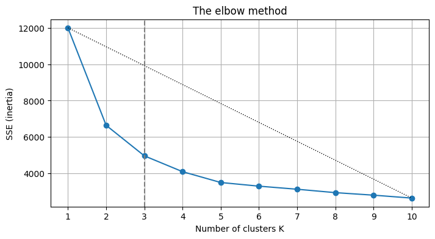

```python
ks = list(range(1, 11))
sse_by_k = [KMeans(n_clusters=k, n_init=10, random_state=0).fit(X).inertia_ for k in ks]

rows = [{'K': k, 'SSE': s, 'reduction vs K-1': (sse_by_k[i - 1] - s) / sse_by_k[i - 1] if i else np.nan}
        for i, (k, s) in enumerate(zip(ks, sse_by_k))]
print(pd.DataFrame(rows).set_index('K').round({'SSE': 0, 'reduction vs K-1': 3}).to_string())

# automatic elbow: distance from each point to the line joining the first and the last point
p1, p2 = np.array([ks[0], sse_by_k[0]]), np.array([ks[-1], sse_by_k[-1]])
d = p2 - p1
dist = [abs(d[0] * (p1[1] - s) - (p1[0] - k) * d[1]) / np.linalg.norm(d) for k, s in zip(ks, sse_by_k)]
elbow = ks[int(np.argmax(dist))]
print(f"\nAutomatic elbow: K = {elbow}")

plt.figure(figsize=(8, 4))
plt.plot(ks, sse_by_k, 'o-')
plt.plot([ks[0], ks[-1]], [sse_by_k[0], sse_by_k[-1]], 'k:', linewidth=1)
plt.axvline(elbow, color='gray', linestyle='--')
plt.xlabel('Number of clusters K')
plt.ylabel('SSE (inertia)')
plt.title('The elbow method')
plt.xticks(ks)
plt.grid(True)
plt.show()
```

The SSE falls quickly at first and then more slowly. As in the book, beyond $K = 5$ the improvements become much smaller: each extra cluster only lowers the SSE by 5 or 6%, compared with 14.5% for the fifth one. The automatic rule, however, points to $K = 3$. The elbow is a heuristic, and two reasonable ways of reading the same curve disagree. As Martha proposes, we decide on a reasonable $K$ and then check whether the groups make clinical sense. Let's compare the groups for several values of $K$:

```python
short = ['age', 'visits_last_year', 'glucose', 'systolic_bp', 'cholesterol', 'chronic_conditions']
for k in [3, 4, 5, 6]:
    km = KMeans(n_clusters=k, n_init=10, random_state=0).fit(X)
    groups = patients.groupby(km.labels_)[short].mean().round(0).astype(int)
    groups['patients'] = np.bincount(km.labels_)
    print(f"K = {k}")
    print(groups.sort_values('age').to_string(index=False), end='\n\n')
```

```
K = 3
 age  visits_last_year  glucose  systolic_bp  cholesterol  chronic_conditions  patients
  35                 4       86          114          175                   0       984
  60                 4      111          135          217                   1       622
  70                13      142          142          207                   4       394

K = 4
 age  visits_last_year  glucose  systolic_bp  cholesterol  chronic_conditions  patients
  35                 4       86          114          174                   0       955
  54                 3      103          132          220                   0       450
  67                20      152          145          216                   5       169
  72                 7      132          139          204                   2       426

K = 5
 age  visits_last_year  glucose  systolic_bp  cholesterol  chronic_conditions  patients
  30                 1       84          113          169                   0       625
  45                 8       90          118          188                   0       428
  53                 2      106          135          224                   0       355
  67                20      152          145          216                   5       169
  72                 7      131          139          204                   2       423

K = 6
 age  visits_last_year  glucose  systolic_bp  cholesterol  chronic_conditions  patients
  30                 1       84          113          169                   0       625
  45                 8       90          118          188                   0       428
  53                 2      106          135          224                   0       344
  67                21      152          146          219                   5       155
  72                 8      133          137          188                   3       208
  73                 7      132          141          218                   2       240
```

With $K = 3$ the silent-risk patients disappear inside a large group of 622 patients aged 60 on average. With $K = 4$ they form the core of a group of 450, but mixed with other patients, which dilutes its averages (3 visits a year, glucose of 103 mg/dL). With $K = 5$ the group appears on its own, with 355 patients. With $K = 6$ nothing new appears: the stable chronic patients are simply split in two by their cholesterol. So $K = 5$ is the choice that is both supported by the curve and clinically meaningful.

### Step 7: The five groups

We run K-Means with $K = 5$. The cluster numbers that the algorithm returns are arbitrary, so we renumber the clusters by increasing mean age. Then we describe each group with the mean of each feature in the original units, its size and the percentage of patients with a family history, the column we left out of the clustering.

```python
scaler = StandardScaler().fit(X_raw)
kmeans5 = KMeans(n_clusters=5, n_init=10, random_state=0).fit(scaler.transform(X_raw))

order = np.argsort(scaler.inverse_transform(kmeans5.cluster_centers_)[:, 0])     # by mean age
renumber = {old: new + 1 for new, old in enumerate(order)}
patients['cluster'] = [renumber[c] for c in kmeans5.labels_]

profile = patients.groupby('cluster')[features].mean().round(1)
profile['patients'] = patients['cluster'].value_counts().sort_index()
profile['% family history'] = (100 * patients.groupby('cluster')['family_history'].mean()).round(0)
print(profile.to_string())
```

```
          age  visits_last_year  glucose  systolic_bp  cholesterol  chronic_conditions  patients  % family history
cluster
1        30.3               1.2     84.2        112.7        169.3                 0.1       625              12.0
2        45.4               8.2     90.3        118.1        188.3                 0.3       428              21.0
3        53.3               1.8    106.4        135.0        224.3                 0.1       355              67.0
4        67.3              20.4    152.0        145.4        216.0                 5.0       169              39.0
5        72.4               7.3    131.4        139.0        203.7                 2.5       423              40.0
```

The five groups match the ones the team finds in the book:

- **Cluster 1** (625 patients): young (30 years on average), about one visit a year, lab results in optimal ranges. "Healthy young people", as Owen labels them.
- **Cluster 2** (428): patients of various ages with frequent visits (8 a year), but normal lab results and almost no chronic conditions: the diverse active cases.
- **Cluster 3** (355): about 53 years old, fewer than two visits a year, glucose of 106 mg/dL and blood pressure of 135 mmHg, both at the top of the normal range, and 67% with a family history. This is the silent-risk group that surprises the team.
- **Cluster 4** (169): the smallest group, with 20 visits a year and 5 chronic conditions: high-complexity patients.
- **Cluster 5** (423): the oldest (72 years), with 2.5 chronic conditions and regular visits: stable chronic patients.

None of these names came from the algorithm, which only produced five centroids: naming the groups is the clinical team's job. Notice also that the family history, which K-Means never saw, is highest in cluster 3, as in the book.

We plot the patients in two of the dimensions, coloured by cluster. The groups overlap in any single pair of features: K-Means separates them using the six features at once.

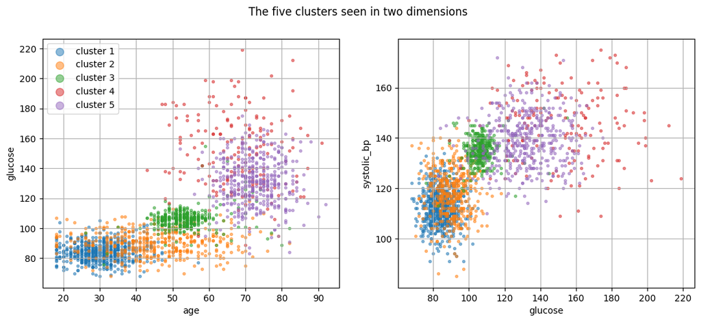

```
Hidden profile (rows) against cluster found by K-Means (columns):
cluster           1    2    3    4    5
hidden profile
0               591    7    2    0    0
1                 0    1   23    5  414
2                34  419   17    0    1
3                 0    1    0  164    8
4                 0    0  313    0    0
ARI = 0.881
```

```python
fig, axes = plt.subplots(1, 2, figsize=(13, 5))
for ax, (fx, fy) in zip(axes, [('age', 'glucose'), ('glucose', 'systolic_bp')]):
    for c in range(1, 6):
        sub = patients[patients['cluster'] == c]
        ax.scatter(sub[fx], sub[fy], s=8, alpha=0.5, label=f'cluster {c}')
    ax.set_xlabel(fx)
    ax.set_ylabel(fy)
    ax.grid(True)
axes[0].legend(markerscale=3)
plt.suptitle('The five clusters seen in two dimensions')
plt.show()

print("Hidden profile (rows) against cluster found by K-Means (columns):")
print(pd.crosstab(hidden_profile, patients['cluster'], rownames=['hidden profile'], colnames=['cluster']).to_string())
print(f"ARI = {adjusted_rand_score(hidden_profile, patients['cluster']):.3f}")
```

Each hidden profile ends up mostly in a single cluster, and all 313 patients of the silent-risk profile are in cluster 3. The errors are at the edges between profiles that overlap, for example 34 active cases younger than usual that end up with the healthy young. With real patients this table would not exist: it is only possible because we generated the data ourselves.

### Step 8: The variables we include decide the groups

Martha's warning, "it only compares numbers using a similarity rule we choose, based on the variables we include", can be tested. We repeat the clustering adding the family history, the yes/no column we had left out:

```python
with_family = StandardScaler().fit_transform(patients[features + ['family_history']])
km_family = KMeans(n_clusters=5, n_init=10, random_state=0).fit(with_family)
print(f"ARI with the family history included: {adjusted_rand_score(hidden_profile, km_family.labels_):.3f}\n")
print("Share of patients with a family history in each new cluster:")
print(pd.Series(patients.groupby(km_family.labels_)['family_history'].mean().round(2).to_numpy(),
                index=[f'cluster {c + 1}' for c in range(5)]).to_string())
```

```
ARI with the family history included: 0.661

Share of patients with a family history in each new cluster:
cluster 1    0.12
cluster 2    1.00
cluster 3    0.40
cluster 4    0.34
cluster 5    0.00
```

The agreement falls from 0.881 to 0.661, and the table explains why: K-Means has spent two of its five clusters separating patients with a family history (cluster 2, all of them) from patients without one (cluster 5, none of them). Once standardized, a yes/no column forms two distant clouds of points, and the squared distance rewards separating them. The algorithm has not made a mistake: it has done exactly what the distance we gave it asks for. Choosing the variables, and therefore what "similar" means, is a clinical decision, not only a technical one.

### Step 9: Assigning a new patient

Once the groups exist, a new patient is assigned to the cluster with the nearest centroid, after applying the same scaling. Liam's example in the book is a patient with a glucose of 105 mg/dL and a blood pressure of 135 mmHg who feels well: in a routine visit, nothing would raise an alarm.

```python
new_patients = pd.DataFrame([
    {'age': 54, 'visits_last_year': 1, 'glucose': 105, 'systolic_bp': 135, 'cholesterol': 220, 'chronic_conditions': 0},
    {'age': 29, 'visits_last_year': 1, 'glucose': 88, 'systolic_bp': 115, 'cholesterol': 175, 'chronic_conditions': 0},
    {'age': 75, 'visits_last_year': 9, 'glucose': 135, 'systolic_bp': 142, 'cholesterol': 200, 'chronic_conditions': 3},
])
new_patients['cluster'] = [renumber[c] for c in kmeans5.predict(scaler.transform(new_patients[features].to_numpy(dtype=float)))]
print(new_patients.to_string(index=False))
```

```
 age  visits_last_year  glucose  systolic_bp  cholesterol  chronic_conditions  cluster
  54                 1      105          135          220                   0        3
  29                 1       88          115          175                   0        1
  75                 9      135          142          200                   3        5
```

The first patient, with the values of Liam's example, falls in cluster 3, the silent-risk group, and could be invited to the prevention program that Minermont launches in the book. The other two are assigned to the healthy young (cluster 1) and to the stable chronic patients (cluster 5).

### Conclusion

- **Unsupervised learning** looks for structure in data without labels. K-Means groups the points around $K$ centroids by alternating two steps, assignment to the nearest centroid and recalculation of each centroid as a mean, and each iteration lowers or keeps the SSE.
- It always converges, but possibly to a **local optimum**: several starts and K-Means++ make that much less likely.
- Distances depend on units, so the features must be **scaled**, and the **variables we include** decide which groups can appear.
- The **elbow method** helps to choose $K$, but it is a heuristic: the final decision combines the curve with the clinical meaning of the groups.
- The algorithm only returns numbers and centroids. Naming the groups, deciding whether they make clinical sense and acting on them (like Minermont's prevention program for the silent-risk group) is the work of the medical team.